# HW1.Q4.Ko

## 4.

```r
library(tidyverse)
library(palmerpenguins)
head(penguins,5)
```

```
## # A tibble: 5 × 8
##   species island bill_length_mm bill_depth_mm flipper_length_… body_mass_g sex
##   <fct>   <fct>           <dbl>         <dbl>            <int>       <int> <fct>
## 1 Adelie  Torge…           39.1          18.7              181        3750 male
## 2 Adelie  Torge…           39.5          17.4              186        3800 fema…
## 3 Adelie  Torge…           40.3          18                195        3250 fema…
## 4 Adelie  Torge…           NA            NA                 NA          NA <NA>
## 5 Adelie  Torge…           36.7          19.3              193        3450 fema…
## # … with 1 more variable: year <int>
```

**(a)** There seems to be a linear relationship between flipper length and body mass.

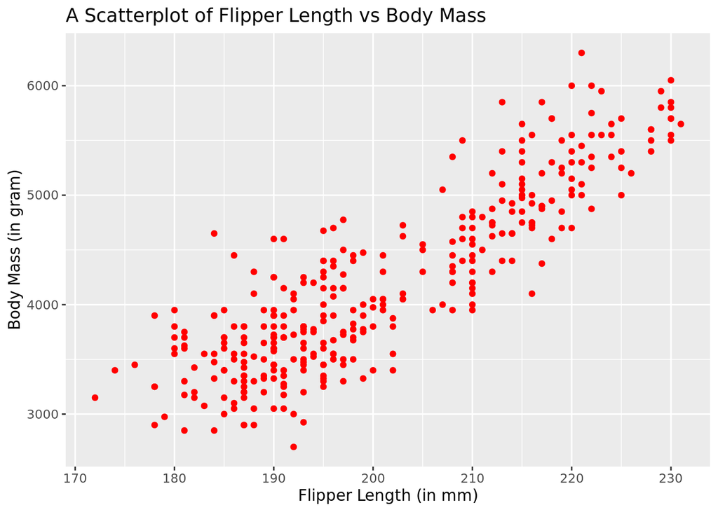

```r
ggplot(penguins, aes(x = flipper_length_mm, y = body_mass_g)) +
  geom_point(colour = "red") +
  labs(x = "Flipper Length (in mm)", y = "Body Mass (in gram)", title = "A Scatterplot of Flipper Length vs Body Mass")
```

**(b)** There seems to be linear relationship between flipper length and body mass across all species. This scatterplot does not influence my answer to the previous part.

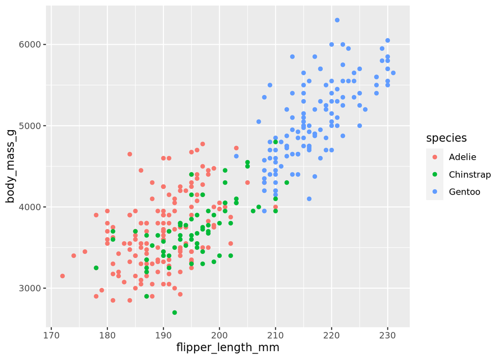

```r
ggplot(penguins, aes(x = flipper_length_mm, y = body_mass_g, color = species)) +
  geom_point(xlab = "Flipper Length (in mm)", ylab = "Body Mass (in gram)", title = "A Scatterplot of Flipper Length vs Body Mass across Species")
```

**(c)** YES. There also seems to be a reasonable linear relationship between flipper length and body mass for Gentoo penguins.

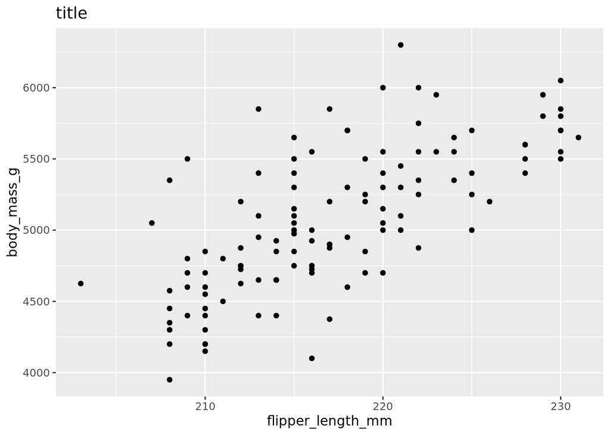

```r
gentoo <- penguins %>%
  filter(species == "Gentoo")

ggplot(gentoo, aes(x = flipper_length_mm, y = body_mass_g, xlab = "Flipper Length (in mm)", ylab = "Body Mass (in gram)", title = "A Scatterplot of Flipper Length vs Body Mass of Gentoo penguins")) +
  geom_point()
```

**(d)** For Gentoo penguins, the correlationship between flipper length and body mass is 0.7026665, which is pretty high. This means flipper length and body mass is in proportional relationship.

```r
cor(gentoo$flipper_length_mm, gentoo$body_mass_g, use = "complete.obs")
```

```
## [1] 0.7026665
```

**(e)** $\hat{y} = -6787.281 + 54.623 * x$

```r
gentoo_result <- lm(body_mass_g ~ flipper_length_mm, data = gentoo)
summary(gentoo_result)
```

```
##
## Call:
## lm(formula = body_mass_g ~ flipper_length_mm, data = gentoo)
##
## Residuals:
##     Min      1Q  Median      3Q     Max
## -911.18 -235.76  -51.93  170.75 1015.71
##
## Coefficients:
##                    Estimate Std. Error t value Pr(>|t|)
## (Intercept)       -6787.281   1092.552  -6.212 7.65e-09 ***
## flipper_length_mm    54.623      5.028  10.863  < 2e-16 ***
## ---
## Signif. codes:  0 '***' 0.001 '**' 0.01 '*' 0.05 '.' 0.1 ' ' 1
##
## Residual standard error: 360.2 on 121 degrees of freedom
##   (1 observation deleted due to missingness)
## Multiple R-squared:  0.4937, Adjusted R-squared:  0.4896
## F-statistic:   118 on 1 and 121 DF,  p-value: < 2.2e-16
```

**(f)** The slope implies 1mm increase of flipper length is proportional 54.623 grams of increase in body mass.

**(g)** The intercept is abnormally small. Body mass cannot be less than zero when flipper length is 0.

**(h)** R2 = 0.4937, which means that about 49.37% of the variation in body mass can be explained by flipper length.

**(i)** $\hat{o} = 360.2$ is the estimated value for standard deviation.

**(j)** The predicted body mass in grams is 5229.779.

```r
y_hat = -6787.281 + 54.623 * 220
y_hat
```

```
## [1] 5229.779
```

**(k)** 0.4937402

```r
gentoo.anova.tab <- anova(gentoo_result)
gentoo.anova.tab
```

```
## Analysis of Variance Table
##
## Response: body_mass_g
##                    Df   Sum Sq  Mean Sq F value    Pr(>F)
## flipper_length_mm   1 15308045 15308045  118.01 < 2.2e-16 ***
## Residuals         121 15696203   129721
## ---
## Signif. codes:  0 '***' 0.001 '**' 0.01 '*' 0.05 '.' 0.1 ' ' 1
```

```r
SST <- sum(gentoo.anova.tab$"Sum Sq")
SSR <- gentoo.anova.tab$"Sum Sq"[1]
SSres <- gentoo.anova.tab$"Sum Sq"[2]

r_2 <- SSR / SST
r_2
```

```
## [1] 0.4937402
```

**(m)** We can derive f statistic from anova table.

```r
f_statistic <- gentoo.anova.tab$`F value`[1]
round(f_statistic, 2)
```

```
## [1] 118.01
```

**(n)** We can use two approaches: P-Value Approach, and Critical Value Approach.

- P-Value Approach: As P-value is 2.2e-16 * 2 < 0.05, so we can reject the null hypothesis.
- Critical Value Approach: As F* (Critical Value = 5.150187) < F-statistic (= 118.01), we can reject the null hypothesis.

```r
qf(0.975, 1, (nrow(gentoo) -2)) # CRITICAL VALUE
```

```
## [1] 5.150187
```

**(o)** When flipper length increases by 1mm, the 95% confidence interval gives that the predicted body mass will increase within the range of (44.66777, 64.57724).

```r
confint(gentoo_result, level = 0.95)
```

```
##                         2.5 %      97.5 %
## (Intercept)       -8950.27535 -4624.28587
## flipper_length_mm    44.66777    64.57724
```

**(p)** According to the result of previous question, there is 95 % chance of having B1 between (44.66777, 64.57724) and 0 is not within the interval. As a result, we can reject the null hypothesis stating that B1 = 0.

**(q)** Estimated mean body mass = 4137.22, 95% CI: (3954.446, 4319.993)

```r
gentooData <- data.frame(flipper_length_mm = 200)

predict(gentoo_result, gentooData, level = 0.95, interval = "confidence")
```

```
##       fit      lwr      upr
## 1 4137.22 3954.446 4319.993
```

**(r)** (3401.121, 4873.319)

```r
predict(gentoo_result, gentooData, level = 0.95, interval = "prediction")
```

```
##       fit      lwr      upr
## 1 4137.22 3401.121 4873.319
```

**(s)** $H_0: \beta_1 = 50$, $H_a: \beta_1 > 50$

```r
critical_value <- qt(0.95, nrow(gentoo) - 2) # ONE-SIDED TEST
critical_value
```

```
## [1] 1.657439
```

```r
t_statistic <- (54.623 - 50) / 5.028
t_statistic
```

```
## [1] 0.9194511
```

```r
p_value <- 1 - pt(t_statistic, nrow(gentoo) - 2)
p_value
```

```
## [1] 0.179837
```